# Monte Carlo: 2025 McDonald’s Pokemon Cards

# Background and Motivation

I was a big fan of the Pokemon games (and I still am!) growing up. While I did start a small Pokemon card collection, I was never serious about being a collector or trading card game (TCG) player. The cards always have pretty and unique art that I enjoy admiring.

On January 21, 2025, McDonalds and Pokemon announced a collaboration, introducing the [Pokemon Happy Meal](https://www.pokemon.com/us/pokemon-news/mcdonalds-pokemon-happy-meals-collaboration). Each Happy Meal came with a TCG four-card booster pack. The collaboration had a set of fifteen cards to collect– seven holofoil and eight standard cards.

Out of boredom, I wondered: “*How many Happy Meals would I have to buy to get all fifteen cards?*” Of course, I wasn’t going to spend who-knows-how-much on Happy Meals– it’d be a lot more faster (and healthier) to run simulations!

# Mathematical Analysis

This is a variation of the [coupon collector’s problem](https://en.wikipedia.org/wiki/Coupon_collector%27s_problem) but with an extra step. Each Happy Meal guarantees one holofoil card and three standard cards with no duplicates. We can treat this as if the holofoil and standard cards are pulled from separate pools. In other words, the expectated number of Happy Meals needed to get all holofoil cards and standard cards are independent of each other.

## Expectation of Holofoil Cards

Let $H$ be the number of Happy Meals required to collect all seven holofoil cards. Let $h_i$ be the number of meals needed to collect the $i$-th new holofoil card after $i-1$ cards have been collected. Note that each $h_i$ follows a [geometric distribution](https://en.wikipedia.org/wiki/Geometric_distribution)– that is, the number of trials for a first success. The total number of meals is $H = h_1 + h_2 + \cdots + h_7$ (Not to be confused with the [harmonic numbers](https://en.wikipedia.org/wiki/Harmonic_number) which will be used in the expectation calculation).

Let $h_i$ be the number of meals needed to collect the next new holofoil provided we already have $i$ unique cards. Let $p_i$ be the probability of pulling a new card we don’t have.
$$\begin{equation*}
E[h_i] = \frac{1}{p_i} = \frac{7}{7 - i + 1}
\end{equation*}$$

Now, we can calculate the expectation of $H$:
$$\begin{align*}
E[H] & = E(h_1 + h_2 + \cdots + h_7) \\
& = \sum_{i=1}^{7} E(h_i) && \text{linearity of
expectation}\\
& = \sum_{i=1}^{7} \frac{7}{7-i+1} \\
& = \frac{7}{7} + \frac{7}{7-1} + \cdots + \frac{7}{1} \\
& = 7 \cdot H_7 && \text{where } H_7 \text{ is the
7th harmonic number} \\
& \approx 18.15 \text{ Happy Meals}
\end{align*}$$

## Expectation of Standard Cards

Calculating the expectation of the standard cards is similar to the holofoil expectation, but we now have to account for the fact that three cards are pulled per pack, meaning we have to consider the possibility of getting 0, 1, 2, or 3 new cards.

We’ll follow the [hypergeometric distribution](https://en.wikipedia.org/wiki/Hypergeometric_distribution). Given a total of $N$ items, suppose $n$ items are drawn where there are $k$ new items left to collect. The expectation is given by $E(X) = n \cdot \frac{k}{N}$

Let $N = 8$, $n = 3$, and $k= 8 - i$ where $i$ represents the number of unique cards already obtained. Let $s_i$ be the number of meals needed to collect new card(s) when $i$ unique cards have already been collected.
$$\begin{align*}
E[s_i \mid i] & = 3 \cdot \frac{8-i}{8}
\end{align*}$$

Let $S$ be the number of Happy Meals required to collect all eight standard cards. It’s important to note that the summation will start from $i = 0$ and go to $i = 7$ as it needs to make sense that we’re considering the range from having $0$ of the unique cards (we have nothing!) to $7$ of the eight cards, meaning we have only one card left to find.

$$\begin{align*}
E[S] & = \sum_{i=0}^{7} \frac{1}{E[s_i \mid i]} \\
& = \sum_{i=0}^{7} \frac{1}{3 \cdot \frac{8-i}{8}} \\
& = \sum_{i=0}^{7} \frac{8}{3(8-i)} \\
& = \frac{8}{3} \sum_{i=0}^{7} \frac{1}{8-i} \\
& = \frac{8}{3} \sum_{j=1}^{8} \frac{1}{j} &&
\text{Reindex of $j = 8 - i$} \\
& = \frac{8}{3} \cdot H_8 && \text{where $H_8$ is
the 8th harmonic number} \\
& \approx 7.25 \text{ Happy Meals} \\
\end{align*}$$

## Putting It Together

With the expectations down (pun very much intended) and foundation laid, we can formalize our original question. We know holofoil and standard cards are pulled independently like separate collection processes in parallel. Ultimately, we really only “wait” on whichever set takes longer to complete. Formally, let $M$ represent the number of meals needed to collect all fifteen Pokemon cards.
$$\begin{align*}
E[M] & = \text{max}(E[H], E[S]) \\
& = \text{max}(18.15, 7.25) \\
& = 18.15 \text{ Happy Meals}
\end{align*}$$
In short, we’re expecting to be bottlenecked by those elusive holofoil cards!

# Uniform Monte Carlo Simulation

## Code

Load necessary helpers.

```r
library(ggplot2)
library(dplyr)
library(tidyr)
library(scales)
```

### `prepare_data.R`

```r
# Given data from one Monte Carlo simulation of n iterations,
# prepare it in a data frame to be merged with the main data frame
#
# @param  raw_data - list of experimental number of total meals
# @return simulation_data - a data frame to bind to the main data frame
prepare_data <- function(raw_data)
{
  # Constant
  actual_mean <- 18.15

  # Prep data
  meals_total_list <- as.numeric(sapply(raw_data, function(x) x$meals_total))
  meals_holofoil_list <- sapply(raw_data, function(x) x$meals_holofoil)
  meals_standard_list <- sapply(raw_data, function(x) x$meals_standard)

  # Get meal values
  meals_total <- mean(meals_total_list)
  meals_holofoil <- mean(meals_holofoil_list)
  meals_standard <- mean(meals_standard_list)

  # Compute error statistics comparing simulation vs analytical expected value
  abs_error <- abs(meals_total - ACTUAL_MEAN)
  std_error <- sd(meals_total_list) / sqrt(n)
  rel_error <- abs((meals_total - ACTUAL_MEAN) / ACTUAL_MEAN) * 100
  variance <- var(meals_total_list)

  # Add experiment for n iterations to experiment data
  simulation_data <- data.frame(Num_Iterations = n,
                                Meals_Holofoil = meals_holofoil,
                                Meals_Standard = meals_standard,
                                Meals_Total = meals_total,
                                Abs_Error = abs_error,
                                Std_Error = std_error,
                                Rel_Error = rel_error,
                                Variance = variance)

  return(simulation_data)
}
```

### `estimate_meals_mc.R`

```r
# Run {#} iterations of buying Happy Meals until all
# fifteen cards are collected.
#
# @return - list of total meals, holofoil meals, and standard
#           meals for one full simulation
# source("prepare_data.R")

estimate_meals <- function(iterations)
{
  summary_data <- data.frame(Iteration_Num = numeric(iterations),
                             Meals_Holofoil = numeric(iterations),
                             Meals_Standard = numeric(iterations),
                             Meals_Total = numeric(iterations))

  for (i in 1:iterations) {
    # Enumerated holofoil (1-7) and standard sets (1-8)
    holofoils_collected <- rep(FALSE, 7)
    standards_collected <- rep(FALSE, 8)

    # Meal counts
    exp_meals_holofoil <- 0
    exp_meals_standard <- 0

    # Collect holofoils
    while (!all(holofoils_collected)) {
      pulled_cards <- sample(x=(1:7), size=1)
      holofoils_collected[pulled_cards] <- TRUE
      exp_meals_holofoil <- exp_meals_holofoil + 1
    }

    # Collect standards
    while (!all(standards_collected)) {
      pulled_cards <- sample(x=(1:8), size=3, replace=FALSE)
      standards_collected[pulled_cards] <- TRUE
      exp_meals_standard <- exp_meals_standard + 1
    }

    # Add current iteration's statistics to data frame
    summary_data$Iteration_Num[i] = i
    summary_data$Meals_Holofoil[i] = exp_meals_holofoil
    summary_data$Meals_Standard[i] = exp_meals_standard
    summary_data$Meals_Total[i] = max(exp_meals_holofoil, exp_meals_standard)
  }

  # Result
  return(summary_data)
}
```

### `experiment.R`

```r
# source("estimate_meals_mc.R")
# Constants and experiment variables
ACTUAL_TOTAL_MEALS <- 18.15
NUM_ITERATIONS <- 10000
set.seed(20250121)

# Run experiment
experiment_data <- estimate_meals(NUM_ITERATIONS)

analysis_data <- data.frame(Iteration_Num = experiment_data$Iteration_Num,
                            Cum_Meals_Total = cumsum(experiment_data$Meals_Total),
                            Mean_Meals_Total = cumsum(experiment_data$Meals_Total) / experiment_data$Iteration_Num,
                            Iteration_Bottleneck = ifelse(experiment_data$Meals_Holofoil >= experiment_data$Meals_Standard,
                                                          "Holofoil",
                                                          "Standard"))
```

## Results and Analysis

First, let’s peek at our experiment numbers:

```r
head(experiment_data)
```

```
##   Iteration_Num Meals_Holofoil Meals_Standard Meals_Total
## 1             1             11              8          11
## 2             2             11              7          11
## 3             3             18              7          18
## 4             4             33              7          33
## 5             5             22              7          22
## 6             6             28              7          28
```

```r
head(analysis_data)
```

```
##   Iteration_Num Cum_Meals_Total Mean_Meals_Total Iteration_Bottleneck
## 1             1              11         11.00000             Holofoil
## 2             2              22         11.00000             Holofoil
## 3             3              40         13.33333             Holofoil
## 4             4              73         18.25000             Holofoil
## 5             5              95         19.00000             Holofoil
## 6             6             123         20.50000             Holofoil
```

Followed by an overview:

```r
summary(experiment_data)
```

```
##  Iteration_Num   Meals_Holofoil  Meals_Standard    Meals_Total
##  Min.   :    1   Min.   : 7.00   Min.   : 3.000   Min.   : 7.0
##  1st Qu.: 2501   1st Qu.:13.00   1st Qu.: 5.000   1st Qu.:13.0
##  Median : 5000   Median :17.00   Median : 6.000   Median :17.0
##  Mean   : 5000   Mean   :18.05   Mean   : 6.592   Mean   :18.1
##  3rd Qu.: 7500   3rd Qu.:22.00   3rd Qu.: 8.000   3rd Qu.:22.0
##  Max.   :10000   Max.   :73.00   Max.   :26.000   Max.   :73.0
```

We see the sample mean is on par with our expected value ($18.1$ vs $18.15$). To further understand this, we can visualize the [law of large numbers](https://en.wikipedia.org/wiki/Law_of_large_numbers) in action:

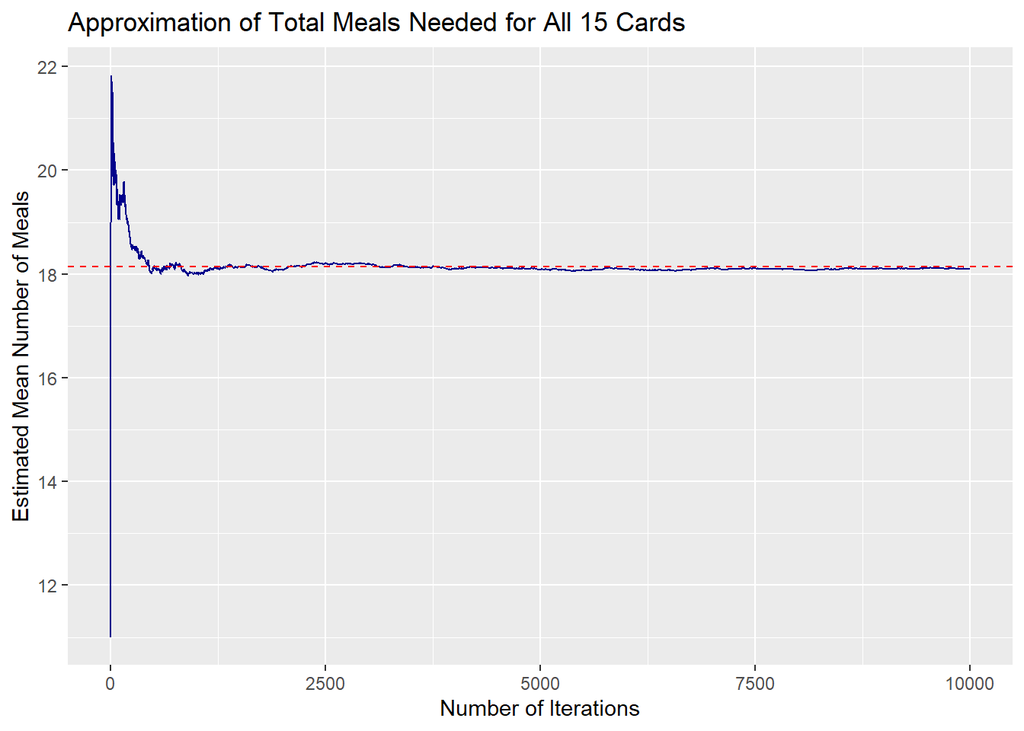

```r
ggplot(analysis_data, aes(x = Iteration_Num, y = Mean_Meals_Total)) +
  geom_line(color = "darkblue") +
  geom_hline(yintercept = ACTUAL_TOTAL_MEALS, linetype = "dashed", color = "red") +
  ylim(c(min(analysis_data$Mean_Meals_Total), max(analysis_data$Mean_Meals_Total))) +
  scale_y_continuous(breaks = pretty_breaks()) +
  labs(title = "Approximation of Total Meals Needed for All 15 Cards",
       x = "Number of Iterations",
       y = "Estimated Mean Number of Meals")
```

Now, let’s visualize the distributions of our meals:

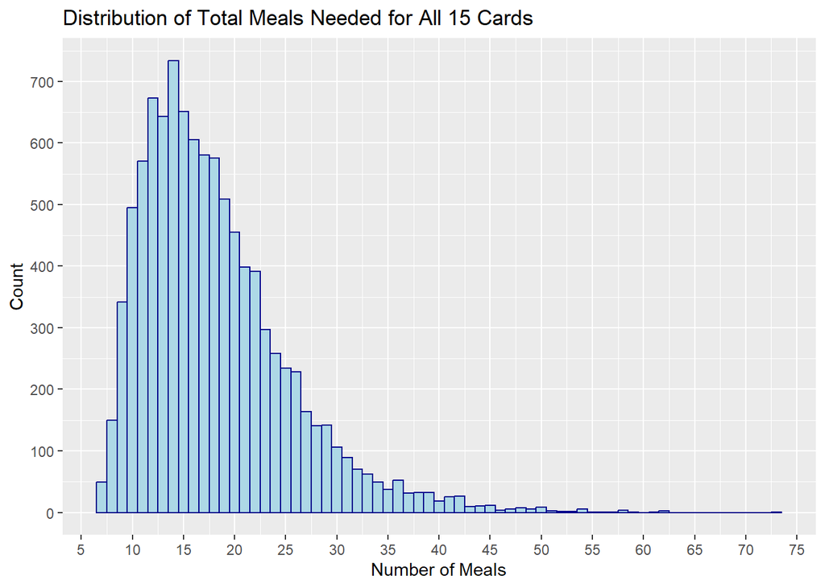

```r
ggplot(experiment_data, aes(x=Meals_Total)) +
  geom_histogram(color="darkblue", fill="lightblue", binwidth=1) +
  scale_x_continuous(breaks = pretty_breaks(max(experiment_data$Meals_Total) / 5)) +
  scale_y_continuous(breaks = pretty_breaks(10)) +
  labs(title = "Distribution of Total Meals Needed for All 15 Cards",
       x = "Number of Meals",
       y = "Count")
```

An interesting question to consider is how many times will holofoil bottleneck the collection of all fifteen cards versus the standard cards? Our theoretical values show it takes over double the meals on average to collect all holofoil cards than the standard cards, but that doesn’t rule out the possibility that standard cards will be the culprit. Based on our experiment, let’s see how many times each card set bottlenecked us.

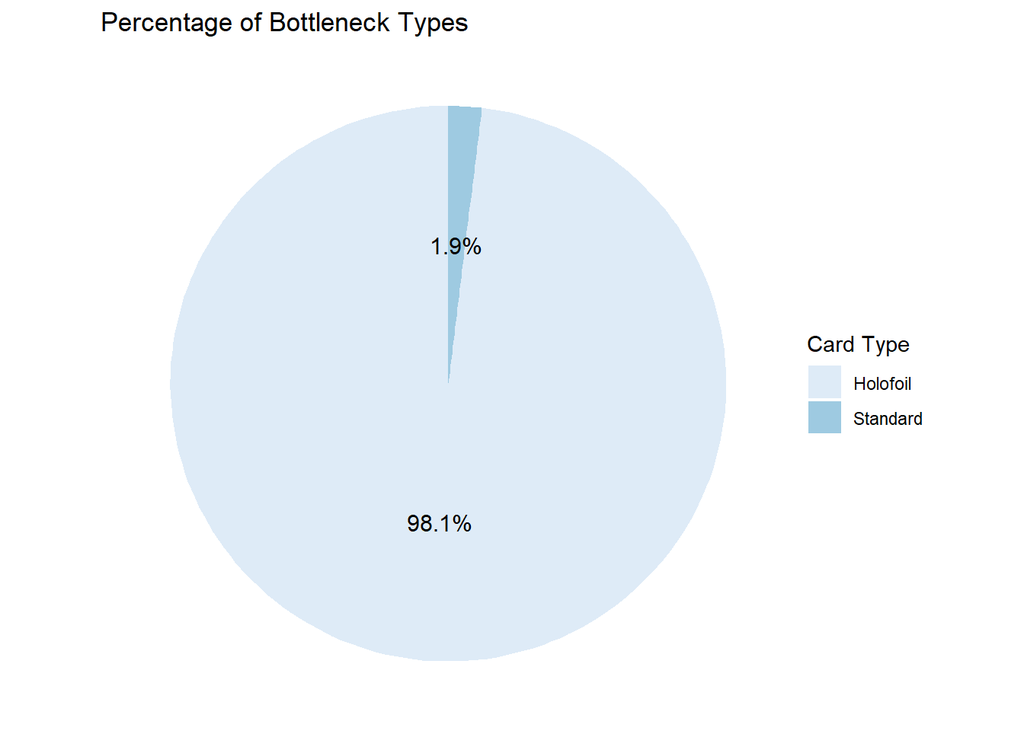

```r
bottlenecks_freqs <- as.data.frame(table(unlist(analysis_data$Iteration_Bottleneck)))
colnames(bottlenecks_freqs) <- c("Card_Type", "Count")
bottlenecks_freqs$Percent <- round(bottlenecks_freqs$Count / sum(bottlenecks_freqs$Count) * 100, 1)
bottlenecks_freqs$Label <- paste0(bottlenecks_freqs$Percent, "%")

ggplot(bottlenecks_freqs, aes(x = "", y = Count, fill = Card_Type)) +
  geom_bar(width = 1, stat = "identity") +
  coord_polar("y", start = 0) +
  geom_text(aes(label = Label),
            position = position_stack(vjust = 0.5),
            color = "black", size = 4) +
  guides(fill = guide_legend(title = "Card Type")) +
  scale_fill_brewer(palette = "Blues") +
  theme_void() +
  labs(title = "Percentage of Bottleneck Types")
```

So, it’s rather rare that our standard cards will be the bottleneck. Let’s see the distributions to get all of the cards in the standard and holofoil sets individually.

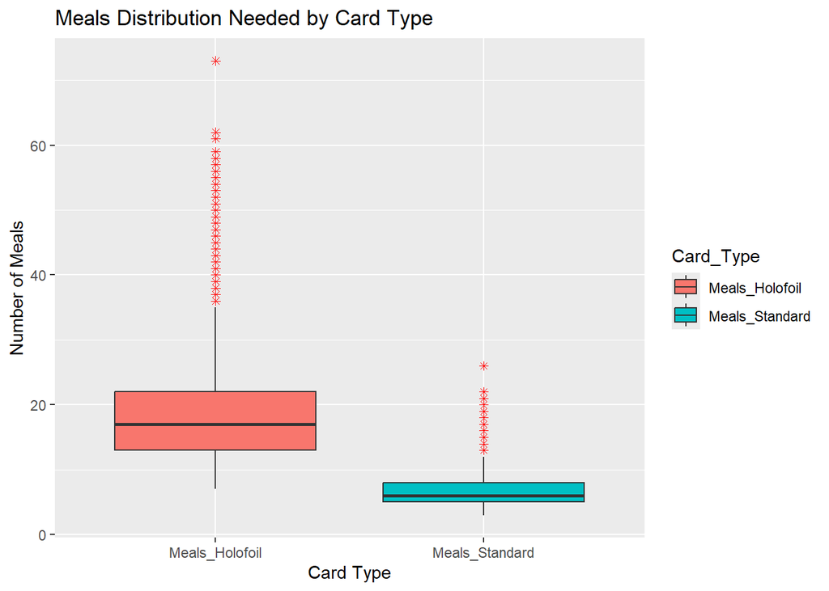

```r
meal_types_df <- experiment_data %>%
  select(Meals_Holofoil, Meals_Standard) %>%
  pivot_longer(cols = everything(),
               names_to = "Card_Type",
               values_to = "Count")

ggplot(meal_types_df, aes(x = Card_Type, y = Count, color = Count, fill = Card_Type)) +
  geom_boxplot(outlier.color = "red", outlier.shape = 8) +
  labs(title = "Meals Distribution Needed by Card Type",
       x = "Card Type",
       y = "Number of Meals")
```

Aha, there are a few outliers that take longer than some of the holofoil cards! On average, it takes around 18 meals to collect all 15 cards, with holofoil cards far more likely to delay completion. The simulation results closely match our theoretical expectations.